# kmean y pca

## COMENZAMOS CON PCA

#### Aquí veremos como es que se aplica el PCA con los datos obtenidos en el web scraping. Veremos la varianza, media y otros conceptos estadísticos, así como gráficas de apoyo

#### comenzamos activando el dataframe

```python
# Cargar el conjunto de datos desde el archivo CSV
df = pd.read_csv('WorldHeritageInDanger.csv')

# Seleccionar solo las columnas numéricas del DataFrame
df_numerico = df.select_dtypes(include=[np.number])

# Quitar valores nulos con la media de la columna
imputer = SimpleImputer(strategy='mean')
df_numerico_imputado = pd.DataFrame(imputer.fit_transform(df_numerico), columns=df_numerico.columns)

# Imprimir los primeros 5 registros del DataFrame imputado
print("Primeros 5 registros del DataFrame imputado:")
print(df_numerico_imputado.head())
```

```
Primeros 5 registros del DataFrame imputado:
   Pais    Latitud   Longitud  Criterio     Año  Peligro
0   1.0  30.841667  29.663889       0.0  1979.0   2001.0
1   2.0  18.283333   8.000000       1.0  1991.0   1992.0
2   3.0  36.233333  37.166667       0.0  1986.0   2013.0
3   3.0  32.518056  36.481667       0.0  1980.0   2013.0
4   3.0  33.511389  36.306389       0.0  1979.0   2013.0
```

#### Exploración inicial de la media y varianza

```python
# Calcular la media de las variables numéricas
print("Media de las variables numéricas:")
media_variables = df_numerico_imputado.mean(axis=0)
print(media_variables)
```

```
Media de las variables numéricas:
Pais          14.321429
Latitud       21.170530
Longitud      20.984957
Criterio       0.285714
Año         1994.035714
Peligro     2009.178571
dtype: float64
```

```python
# Calcular la varianza de las variables numéricas
print("Varianza de las variables numéricas:")
varianza_variables = df_numerico_imputado.var(axis=0)
print(varianza_variables)
```

```
Varianza de las variables numéricas:
Pais          88.476623
Latitud      263.391518
Longitud    2511.274568
Criterio       0.207792
Año          183.016883
Peligro      108.949351
dtype: float64
```

#### Se crea un modelo PCA utilizando un pipeline que combina la estandarización de datos y el análisis de componentes principales (PCA).

```python
# Crear un pipeline para el modelo PCA que incluye la estandarización de los datos y PCA
pca_pipe = make_pipeline(StandardScaler(), PCA())

# Ajustar el modelo PCA al DataFrame de datos numéricos imputados
pca_pipe.fit(df_numerico_imputado)

# Extraer el modelo PCA del pipeline
pca_model = pca_pipe.named_steps['pca']
```

#### Este DataFrame permite interpretar cómo cada variable contribuye a los diferentes componentes principales. Los valores en cada fila (componente principal) indican la importancia relativa de cada variable en ese componente específico.

```python
pd.DataFrame(
    pca_model.components_,
    columns=df_numerico_imputado.columns,
    index = ['PC' + str(i) for i in range(1, len(df_numerico_imputado.columns) + 1)]

)
```

|  | Pais | Latitud | Longitud | Criterio | Año | Peligro |
| --- | --- | --- | --- | --- | --- | --- |
| PC1 | 0.105619 | -0.479613 | -0.259073 | 0.519315 | -0.415572 | -0.499308 |
| PC2 | 0.664006 | -0.285135 | 0.331139 | 0.322452 | 0.482901 | 0.175987 |
| PC3 | -0.424510 | -0.178447 | 0.853669 | 0.075575 | -0.078178 | -0.217656 |
| PC4 | -0.209477 | -0.639512 | -0.073020 | -0.098777 | -0.226257 | 0.693442 |
| PC5 | -0.484947 | -0.304352 | -0.296331 | 0.052265 | 0.732636 | -0.211890 |
| PC6 | 0.297787 | -0.393979 | 0.036517 | -0.779831 | -0.006885 | -0.382866 |

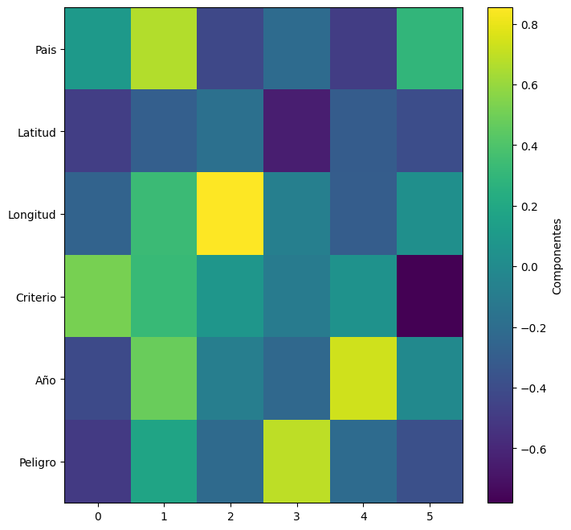

```python
components_df = pd.DataFrame(
    pca_model.components_,
    columns=df_numerico_imputado.columns,
    index = ['PC' + str(i) for i in range(1, len(df_numerico_imputado.columns) + 1)]
)

# Crear una figura y un eje para visualizar los componentes principales
fig, ax = plt.subplots(nrows=1, ncols=1, figsize=(8, 8))

# Obtener los componentes principales del modelo PCA
components = pca_model.components_

# Visualizar los componentes principales como una matriz de calor
plt.imshow(components.T, cmap='viridis', aspect='auto')

# Configurar las etiquetas del eje y con los nombres de las variables originales
plt.yticks(range(len(df_numerico_imputado.columns)), df_numerico_imputado.columns)

# Ocultar las líneas de la cuadrícula
plt.grid(False)

# Agregar una barra de color para indicar la magnitud de los componentes
plt.colorbar(label='Componentes')

# Mostrar la figura
plt.show()
```

#### Aquí se calcula la varianza explicada por cada componente principal del modelo PCA y se visualiza gráficamente en un gráfico de barras.

```
Varianza explicada por cada componente:
[0.36790249 0.24549759 0.14807348 0.09850403 0.07439266 0.06562974]
```

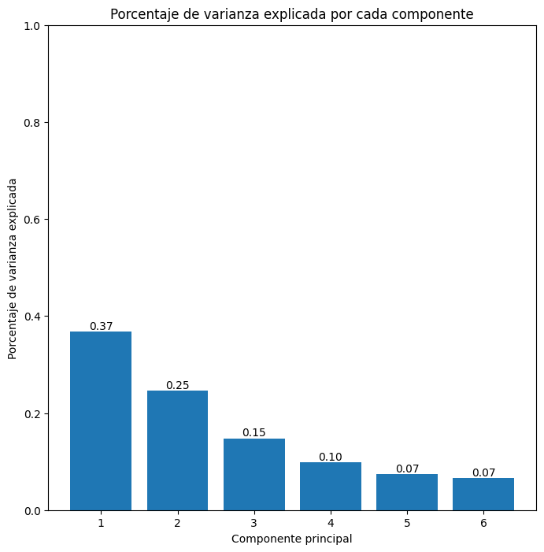

```python
# Varianza explicada por cada componente
print('Varianza explicada por cada componente:')
print(pca_model.explained_variance_ratio_)

# Visualización de la varianza explicada
fig, ax = plt.subplots(nrows=1, ncols=1, figsize=(8, 8))
ax.bar(
    x=range(1, len(df_numerico_imputado.columns) + 1),
    height=pca_model.explained_variance_ratio_
)
for x, y in zip(range(1, len(df_numerico_imputado.columns) + 1), pca_model.explained_variance_ratio_):
    ax.text(x, y, f'{y:.2f}', ha='center', va='bottom')
ax.set_xticks(range(1, len(df_numerico_imputado.columns) + 1))
ax.set_ylim(0, 1)
ax.set_title('Porcentaje de varianza explicada por cada componente')
ax.set_xlabel('Componente principal')
ax.set_ylabel('Porcentaje de varianza explicada')

plt.show()  # Mostrar la figura solo una vez
```

#### calcula y visualiza la varianza explicada acumulada por los componentes principales del modelo PCA.

```
Varianza explicada acumulada:
[0.36790249 0.61340009 0.76147357 0.8599776  0.93437026 1.        ]
```

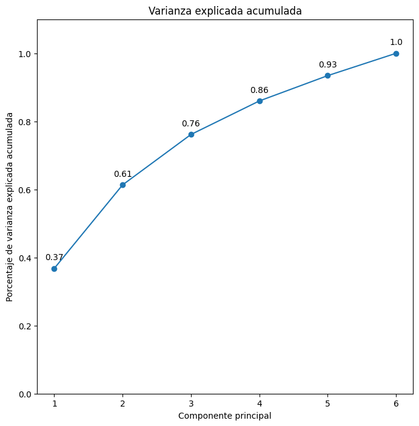

```python
# Calcular la varianza explicada acumulada por los componentes principales
prop_var_acum = pca_model.explained_variance_ratio_.cumsum()

# Imprimir la varianza explicada acumulada
print('Varianza explicada acumulada:')
print(prop_var_acum)

# Visualización de la varianza explicada acumulada
fig, ax = plt.subplots(nrows=1, ncols=1, figsize=(8, 8))

# Graficar la varianza explicada acumulada
ax.plot(
    np.arange(len(df_numerico_imputado.columns)) + 1,  # Componentes principales en el eje x
    prop_var_acum,  # Varianza explicada acumulada en el eje y
    marker='o'  # Marcadores circulares en los puntos
)

# Etiquetar cada punto con el porcentaje acumulado correspondiente
for x, y in zip(np.arange(len(df_numerico_imputado.columns)) + 1, prop_var_acum):
    label = round(y, 2)
    ax.annotate(
        label,
        (x, y),
        textcoords="offset points",
        xytext=(0, 10),
        ha='center'
    )

# Configurar límites y etiquetas de ejes
ax.set_ylim(0, 1.1)
ax.set_xticks(np.arange(len(df_numerico_imputado.columns)) + 1)
ax.set_title('Varianza explicada acumulada')
ax.set_xlabel('Componente principal')
ax.set_ylabel('Porcentaje de varianza explicada acumulada')

# Mostrar la figura
plt.show()
```

#### Realizamos la transformación de los datos originales del DataFrame df_numerico_imputado al espacio de los componentes principales utilizando el modelo PCA previamente ajustado.

```python
# Obtener los nombres de los sitios del patrimonio mundial del DataFrame original
nombre = df['Name']

# Transformar los datos originales al espacio de los componentes principales utilizando el modelo PCA
proyecciones = pca_pipe.transform(df_numerico_imputado)

# Crear un nuevo DataFrame que contenga las proyecciones en el espacio de los componentes principales
proyecciones = pd.DataFrame(
    proyecciones,
    columns=df_numerico_imputado.columns,
    index=['Name ' + str(i) for i in range(1, len(df_numerico_imputado) + 1)]
)
proyecciones
```

|  | Pais | Latitud | Longitud | Criterio | Año | Peligro |
| --- | --- | --- | --- | --- | --- | --- |
| Name 1 | 0.047784 | -1.947127 | 0.860497 | -0.329991 | -0.228937 | 0.147566 |
| Name 2 | 1.758627 | -0.804824 | 0.868596 | -0.845767 | 1.041739 | -0.928075 |
| Name 3 | -0.925677 | -1.393937 | 0.545253 | 0.085959 | -0.343063 | -0.362841 |
| Name 4 | -0.625336 | -1.548750 | 0.609685 | 0.335947 | -0.596545 | -0.269257 |
| Name 5 | -0.623046 | -1.603547 | 0.601482 | 0.313584 | -0.668942 | -0.293204 |
| Name 6 | -1.701916 | -0.497414 | 0.392813 | -0.339475 | 1.023093 | -0.378386 |
| Name 7 | -0.753675 | -1.457389 | 0.234591 | 0.490129 | -0.519282 | -0.367647 |
| Name 8 | -0.708643 | -1.504523 | 0.106621 | 0.508674 | -0.470609 | -0.368637 |
| Name 9 | -0.704190 | -1.519538 | 0.073690 | 0.504694 | -0.462980 | -0.374056 |
| Name 10 | -0.955908 | -0.754877 | 0.678857 | -0.894321 | 0.665029 | 0.085950 |
| Name 11 | 2.340301 | -1.628514 | -0.529356 | 0.142665 | 1.586650 | 1.733094 |
| Name 12 | 1.241713 | -0.752689 | -0.813603 | 2.416911 | 1.153330 | 1.018997 |
| Name 13 | 0.597482 | -1.194135 | -1.115972 | 0.462999 | 1.050272 | 0.618730 |
| Name 14 | -1.497607 | -0.653858 | 0.429204 | -0.192512 | 0.782710 | -0.338217 |
| Name 15 | -1.020099 | -0.295090 | 0.925869 | -0.995484 | 0.322190 | 0.247095 |
| Name 16 | 0.718354 | 1.920387 | 2.969970 | 1.231841 | 0.236919 | -0.607432 |
| Name 17 | 2.438487 | -1.296620 | -1.099050 | -0.927359 | 0.294862 | -0.909096 |
| Name 18 | 0.815532 | -1.291941 | -1.520652 | 1.150509 | 0.083254 | 0.532384 |
| Name 19 | 2.925446 | -0.158681 | 1.123877 | -0.906930 | 0.175745 | 0.090570 |
| Name 20 | -0.978277 | -1.205011 | 0.520510 | 0.209459 | -0.563637 | -0.352574 |
| Name 21 | -1.803854 | 0.643995 | -0.203733 | -0.225970 | 0.798155 | -0.061574 |
| Name 22 | -2.691506 | 0.739041 | -0.651580 | -0.535978 | 0.694032 | -0.624503 |
| Name 23 | -0.862809 | -0.065818 | -0.345987 | 1.041869 | -0.572006 | 0.005393 |
| Name 24 | -1.110782 | 0.222330 | -0.392636 | 0.906861 | -0.134841 | 0.001285 |
| Name 25 | -1.595894 | 0.235241 | 0.287178 | -0.396939 | -0.546086 | -0.112963 |
| Name 26 | -1.673415 | -0.139206 | -0.754232 | -0.658865 | -0.435966 | -0.379785 |
| Name 27 | 0.279743 | 0.137109 | 0.445051 | -0.373688 | -0.094356 | 1.138140 |
| Name 28 | 0.564072 | 0.400166 | -2.731213 | 0.151412 | 0.911700 | -1.709204 |
| Name 29 | 2.494385 | 0.174386 | 0.913862 | 0.223727 | 0.035438 | -0.231739 |
| Name 30 | 0.827093 | 1.595859 | 0.125769 | 0.955135 | 0.018766 | -0.924416 |
| Name 31 | -1.807457 | 1.600669 | -0.192745 | 0.610120 | 1.038624 | 0.242880 |
| Name 32 | 2.031949 | 0.780169 | 0.250687 | -0.537649 | -0.117933 | -0.267314 |
| Name 33 | -0.910584 | -0.362478 | 0.900665 | -1.023470 | 0.316018 | 0.292849 |
| Name 34 | -1.033966 | 0.262054 | -0.639496 | -1.344751 | -0.225273 | 0.324081 |
| Name 35 | 2.710567 | 0.411004 | -0.192505 | -0.700039 | -0.297277 | -0.002447 |
| Name 36 | -1.518003 | 2.562492 | 1.759700 | 0.299466 | -0.024376 | 0.990663 |
| Name 37 | 1.870510 | 0.684369 | -0.732741 | 0.052151 | -0.785206 | -0.629167 |
| Name 38 | 1.865556 | 0.669238 | 0.766340 | -0.224847 | 0.826106 | -0.350368 |
| Name 39 | 1.129219 | -0.396989 | 0.195512 | -2.244592 | -1.081951 | 1.629596 |
| Name 40 | -0.266425 | 0.125632 | 0.172752 | 0.702733 | -0.811318 | 0.558898 |
| Name 41 | -0.732928 | -1.347999 | 0.028701 | 0.547819 | -0.176025 | -0.312855 |
| Name 42 | 0.022876 | 0.556316 | -1.091924 | 0.663090 | -0.872332 | 0.808007 |
| Name 43 | -1.572002 | 0.481578 | -0.124913 | -0.384258 | 0.691840 | 0.046230 |
| Name 44 | -0.182527 | 0.000890 | 0.265689 | 0.741021 | -1.067077 | 0.550204 |
| Name 45 | 1.447489 | 2.788357 | 0.292678 | 0.747483 | 0.565679 | 0.060945 |
| Name 46 | -2.200168 | 1.983750 | -1.068076 | -0.379053 | 0.163340 | 0.121562 |
| Name 47 | 2.720924 | 0.360617 | -2.003028 | -0.817732 | -0.387624 | -0.182992 |
| Name 48 | -0.548234 | -1.284502 | 0.107659 | 0.774205 | -0.135352 | -0.181903 |
| Name 49 | -1.238648 | -0.516444 | 0.595696 | -0.644601 | 0.821851 | -0.032927 |
| Name 50 | 1.150423 | 1.346397 | -0.671304 | -0.004649 | -1.541486 | -0.872494 |
| Name 51 | -0.695364 | -1.572945 | 0.617777 | 0.252364 | -0.645725 | -0.317820 |
| Name 52 | 0.122346 | 0.447811 | -1.012828 | 0.278664 | -0.853929 | 0.886974 |
| Name 53 | -0.374593 | 1.052383 | -1.049966 | 0.023533 | 0.011920 | 0.892777 |
| Name 54 | 0.910468 | 3.115480 | 0.864604 | 0.223289 | -0.362358 | -0.101787 |
| Name 55 | 2.566131 | 0.029536 | 0.952072 | -0.096970 | -0.024895 | -0.203574 |
| Name 56 | -2.283948 | 1.867590 | -1.546369 | -1.022426 | -0.261874 | 0.024382 |

# CLUSTER

#### es una técnica de aprendizaje no supervisado utilizada para agrupar datos en clusters o grupos basados en su similitud.

#### Comenzamos con una función que visualiza el proceso de agrupamiento realizado por el algoritmo K-Means.

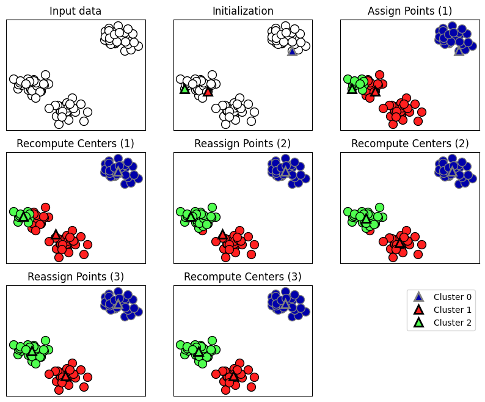

```python
mglearn.plots.plot_kmeans_algorithm()
plt.show()
```

#### Ejecutar k-means con 3 clusters

```python
# Crear un objeto KMeans con 3 clusters
kmedias = KMeans(n_clusters=3)

# Ajustar el modelo KMeans a los datos del DataFrame df_numerico_imputado
kmedias.fit(df_numerico_imputado)

# Predecir a qué cluster pertenece cada punto de datos en el conjunto de datos
predicciones = kmedias.predict(df_numerico_imputado)
print(predicciones)

# Obtener las coordenadas de los centroides de los clusters encontrados por KMeans
centros = np.array(kmedias.cluster_centers_)
print(centros)
```

```
[0 0 0 0 0 0 0 0 0 0 1 1 1 0 0 2 1 1 0 0 0 0 0 0 0 0 0 1 0 0 0 0 0 0 0 2 0
 0 0 0 0 0 0 0 0 0 1 0 0 0 0 0 0 2 0 0]
[[ 1.39782609e+01  2.45852772e+01  2.88576655e+01  2.39130435e-01
   1.99426087e+03  2.00976087e+03]
 [ 1.32857143e+01  8.85289683e+00 -8.17584127e+01  4.28571429e-01
   1.98742857e+03  2.00357143e+03]
 [ 2.20000000e+01 -2.44777778e+00  1.40004630e+02  6.66666667e-01
   2.00600000e+03  2.01333333e+03]]
```

#### Funcion para calcular los centroides de cada cluster

```python
def centroide(num_cluster,datos,clusters):
  ind = clusters == num_cluster
  return (pd.DataFrame(datos[ind].mean()).T)
```

#### Ejemplo con varias funciones de agregación, declaracion de intancia de clases. Aquí se construye dendrogramas de el DataFrame

#### A su vez podremos observar todo el proceso por medio de gráficas

```python
complete_res = linkage(df_numerico_imputado, method='complete')
single_res = linkage(df_numerico_imputado, method='single')
average_res = linkage(df_numerico_imputado, method='average')
word_res = linkage(df_numerico_imputado, method='ward')
```

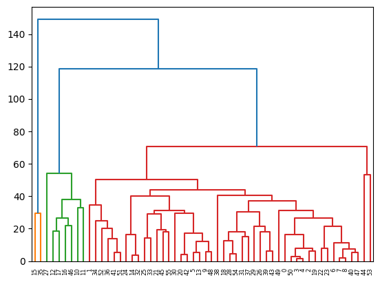

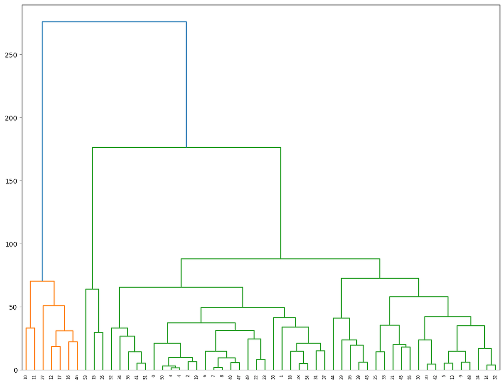

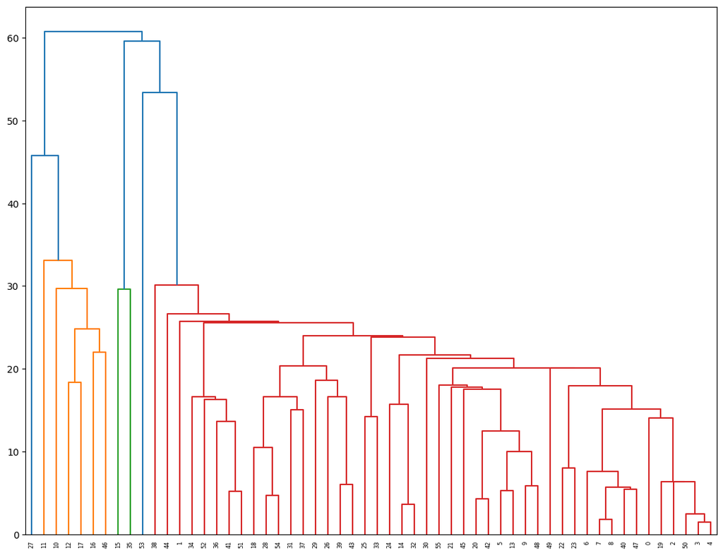

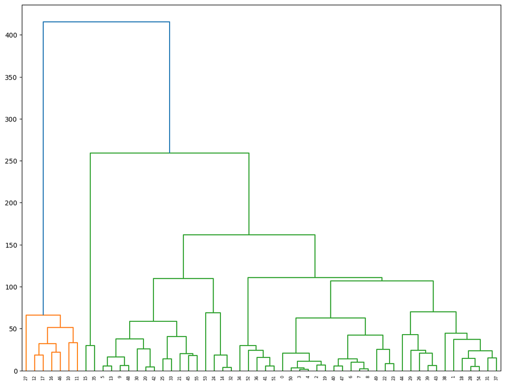

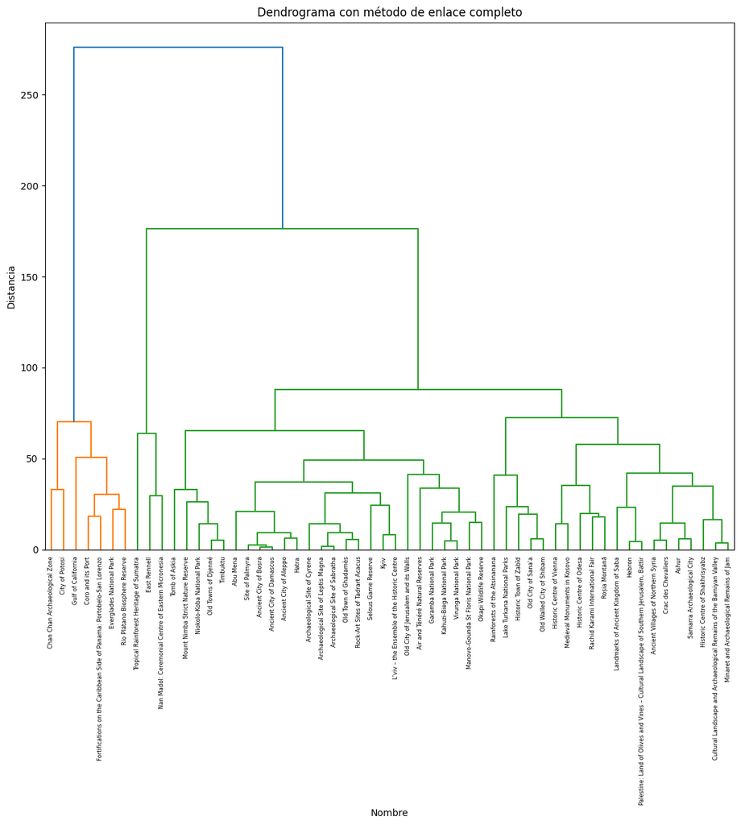

```python
from scipy.cluster.hierarchy import dendrogram, linkage

dendrogram(average_res, labels=df_numerico_imputado.index.tolist())
plt.figure(figsize=(13,10))
dendrogram(complete_res, labels=df_numerico_imputado.index.tolist())
plt.figure(figsize=(13,10))
dendrogram(single_res, labels=df_numerico_imputado.index.tolist())
plt.figure(figsize=(13,10))
dendrogram(word_res, labels=df_numerico_imputado.index.tolist())
#impriir dendrograma
plt.figure(figsize=(13, 10))
dendrogram(complete_res, labels=df['Name'].tolist())
plt.title('Dendrograma con método de enlace completo')
plt.xlabel('Nombre')
plt.ylabel('Distancia')
plt.show()
```

#### Interpretacion con 3 cluster en grafico barra

#### Análisis de clustering jerárquico aglomerativo utilizando el método de enlace de Ward y asigna los datos a tres grupos.

```python
# Realizar clustering jerárquico aglomerativo y asignar los datos a tres grupos
grupos = fcluster(linkage(pdist(df_numerico_imputado), method='ward', metric='euclidean'), 3, criterion='maxclust')
grupos = grupos - 1  # Ajustar los índices de los grupos para que comiencen desde cero
print(grupos)

# Calcular los centroides de cada grupo
centros = np.array(pd.concat([centroide(0, df_numerico_imputado, grupos),
                              centroide(1, df_numerico_imputado, grupos),
                              centroide(2, df_numerico_imputado, grupos)]))
print(centros)

# Visualizar los centroides en un gráfico
plt.figure(1, figsize=(12, 8))
```

```
[2 2 2 2 2 2 2 2 2 2 0 0 0 2 2 1 0 0 2 2 2 2 2 2 2 2 2 0 2 2 2 2 2 2 2 1 2
 2 2 2 2 2 2 2 2 2 0 2 2 2 2 2 2 2 2 2]
[[ 1.32857143e+01  8.85289683e+00 -8.17584127e+01  4.28571429e-01
   1.98742857e+03  2.00357143e+03]
 [ 1.70000000e+01 -2.42166667e+00  1.59256944e+02  5.00000000e-01
   2.00700000e+03  2.01450000e+03]
 [ 1.43617021e+01  2.40089947e+01  3.04032471e+01  2.55319149e-01
   1.99446809e+03  2.00978723e+03]]
```

#### Nos ayuda a visualizar los centroides de los clusters en un análisis de clustering mediante gráficos de barras horizontales.

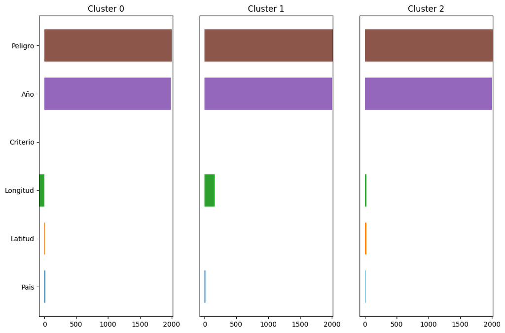

```python
def bar_plot(centros, labels, cluster=None, var=None):
  from math import ceil, floor
  from seaborn import color_palette
  colores = color_palette()
  minimo = floor(centros.min()) if floor(centros.min()) < 0 else 0
  def inside_plot(valores,labels,titulo):
    plt.barh(range(len(valores)), valores, 1/1.5, color=colores)
    plt.xlim(minimo, ceil(centros.max()))
    plt.title(titulo)
  if var is not None:
    centros = np.array(n[[x in var for x in labels]] for n in centros)
    colores = [colores[x % len(colores)] for x, i in enumerate(labels) if i in var]
    labels = labels[[x in var for x in labels]]
  if cluster is None:
    for i in range(len(centros)):
      plt.subplot(1,centros.shape[0],i+1)
      inside_plot(centros[i].tolist(),labels,"Cluster "+str(i))
      plt.yticks(range(len(labels)), labels) if i == 0 else plt.yticks([])
  else:
    pos = 1
    for i in cluster:
      plt.subplot(1,len(cluster),pos)
      inside_plot(centros[i].tolist(),labels,"Cluster "+str(i))
      plt.yticks(range(len(labels)), labels) if pos == 1 else plt.yticks([])
      pos += 1
  plt.show()
plt.figure(1, figsize=(12, 8))
bar_plot(centros, df_numerico_imputado.columns)
```

## MAPA DE LOS PAISES EN PELIGRO

### NOTA IMPORTANTE: Este mapa solo se puede visualizar si se ve el HTML en un computador, de lo contario no se puede observar. en caso de que no se logre visualizar, se colocó una imagen de como se ve el mapa en la carpeta de la actividad :)

#### Aquí veremos un mapa del mundo donde cada punto esta colocado de acuerdo a las coordenadas quetenemos y los colores significas:

#### Verde: criterio es natural

#### Azul: criteo es cultural

```python
# Crear un mapa centrado en una ubicación inicial
mapa = folium.Map(location=[0, 0], zoom_start=2)

# Agregar marcadores para cada ubicación (latitud y longitud)
for i in range(len(df_numerico_imputado)):
    # Determinar el color del marcador según el criterio
    if df_numerico_imputado.iloc[i]['Criterio'] == 0:
        color = 'blue'  # Cultural
    else:
        color = 'green'  # Natural

    folium.CircleMarker(
        location=[df_numerico_imputado.iloc[i]['Latitud'], df_numerico_imputado.iloc[i]['Longitud']],
        radius=5,
        color=color,
        fill=True,
        fill_color=color,
        popup=df.iloc[i]['Name']
    ).add_to(mapa)

# Guardar el mapa en un archivo HTML
mapa.save('mapa.html')

# Mostrar el mapa en el cuaderno
mapa
```

[interactive chart not shown]

## BIBLIOGRAFÍAS

#### (S/f). Iebschool.com. Recuperado el 20 de mayo de 2024, de https://www.iebschool.com/blog/algoritmo-k-means-que-es-y-como-funciona-big-data/

#### Wikipedia. (n.d.). List of World Heritage in Danger. Recuperado el 20 de mayo de 2024, de https://en.wikipedia.org/wiki/List_of_World_Heritage_in_Danger

#### Wikipedia. (n.d.). List of World Heritage in Danger. Recuperado el 20 de mayo de 2024, de https://en.wikipedia.org/wiki/List_of_World_Heritage_in_Danger

## CONCLUSIÓN

#### Aunque enfrentamos algunos desafíos, cada obstáculo superado nos enseñó algo nuevo. Nos encantó ver cómo los conceptos a través de las visualizaciones gráficas, es increible cómo una simple gráfica puede hacer que todo tenga más sentido. Este proceso nos dejó con un mayor entendimiento de los conceptos.